# Integrative Bayesian Multi-Platform Regression with IntegMultiReg

Sinian Zhang, Thierry Chekouo

# 1 Overview

`IntegMultiReg` implements the *integrative multi-regression* (IMR) model of Chekouo, Stingo, Doecke and Do (2017) and extends it from time-to-event outcomes to continuous (Gaussian) and binary (probit) outcomes. The central idea is to integrate **all** available subjects across several molecular platforms, even when many subjects are measured on only a subset of the platforms.

Given $K$ platforms, subjects are partitioned into the $2^K-1$ non-empty **availability subgroups** of a $K$-set Venn diagram. One regression model is built per subgroup, and information is shared across availability subgroups through

- **non-local (product moment) priors** on the regression coefficients, which sharply penalise small effects and yield parsimonious models, and
- a **Markov random field (MRF) prior** on the variable-selection indicators, which encourages the same biomarkers to be selected across availability subgroups.

```r
library(IntegMultiReg)
data("simIMR", package = "IntegMultiReg")
sapply(simIMR$platforms, dim)
```

```
#>      genomic proteomic metabolomic
#> [1,]     240       180         180
#> [2,]      21        11           9
```

The bundled `simIMR` data set has three platforms (`genomic`, `proteomic`, `metabolomic`) measured on overlapping but partially missing sets of subjects, clinical covariates for everyone, and three outcome types generated from the same latent signal. The truly associated features are recorded in `simIMR$truth`.

# 2 Real TCGA-KIRC example

The package also includes `kircIMR`, a reduced real-data example derived from public UCSC Xena TCGA kidney renal clear cell carcinoma (KIRC) sampleMap files, not from controlled-access TCGA/GDC files. It mirrors the case-study structure of Chekouo et al. (2017): mRNA expression, miRNA expression and DNA methylation measured on overlapping patient sets, clinical covariates, and a right-censored survival outcome. Patient IDs are package-internal labels such as `KIRC001`; the package does not distribute TCGA barcodes, and users should not attempt participant re-identification or linkage to external resources.

```r
data("kircIMR", package = "IntegMultiReg")
sapply(kircIMR$platforms, dim)
```

```
#>      mrna mirna methylation
#> [1,]  521   235         312
#> [2,]   51    31          51
```

```r
kircIMR$model_subgroup_sizes
```

```
#> bitstrings
#> 011 101 001 111
#>  63 139 147 172
```

The original Biometrics analysis used a much larger screened panel (776 mRNA, 91 miRNA and 729 methylation features) and long MCMC chains. The package object keeps a smaller Cox-screened panel (50, 30 and 50 features) so that examples remain lightweight while retaining the same scientific data structure. A short survival fit follows the same call pattern:

```r
kirc_fit <- imr(
  platform_data_list = kircIMR$platforms,
  outcome            = kircIMR$outcome.survival,
  cov                = kircIMR$covariates,
  type_outcome       = "right.censored",
  nu                 = c(-4, -3, -4),
  sample_mcmc        = c(4000, 1000),
  ssize              = 30,
  seed               = 1
)
summary(kirc_fit)
plot_top_features(kirc_fit, top = 12)
```

# 3 Fitting the model

The workhorse is `imr()`. Here we fit a binary (probit) outcome with a short MCMC run for illustration; in practice use longer chains.

```r
fit <- imr(
  platform_data_list = simIMR$platforms,
  outcome            = simIMR$outcome.binary,
  cov                = simIMR$covariates,
  type_outcome       = "binary",
  nu                 = c(-4, -3, -4),
  sample_mcmc        = c(1500, 500),
  ssize              = 30,
  seed               = 1
)
fit
```

```
#> Integrative Bayesian Multi-Platform Regression (IMR)
#> ----------------------------------------------------
#> Call:
#>   imr(platform_data_list = simIMR$platforms, outcome = simIMR$outcome.binary,
#>     cov = simIMR$covariates, type_outcome = "binary", ssize = 30,
#>     nu = c(-4, -3, -4), sample_mcmc = c(1500, 500), seed = 1)
#>
#> Outcome type : binary
#> Method       : IMR
#> Platforms    : 3 (genomic, proteomic, metabolomic)
#> MCMC         : 1500 retained draws after 500 burn-in
#>
#> Platform key:
#>   P1 = genomic
#>   P2 = proteomic
#>   P3 = metabolomic
#>
#> Availability subgroups modelled (bitstring : platforms : size):
#>   011 : P1 + P2      : 120
#>   100 : P3           : 60
#>   101 : P1 + P3      : 60
#>   111 : P1 + P2 + P3 : 60
#>
#> Features with mPIP > 0.50 (in any subgroup):
#>   genomic      : 2 of 20
#>   proteomic    : 2 of 10
#>   metabolomic  : 2 of 8
```

The four modelled availability subgroups correspond to the availability patterns `011` (genomic + proteomic), `111` (all three), `101` (genomic + metabolomic) and `100` (metabolomic only); the bitstring digits run from the first platform (right) to the last (left). `plot_subgroup_sizes()` shows how the sample splits across them.

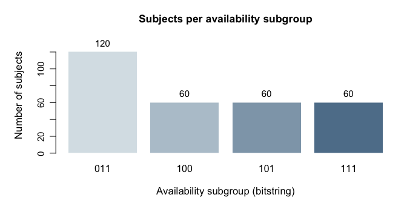

```r
plot_subgroup_sizes(fit)
```

# 4 Inspecting selected biomarkers

`summary()` ranks, per platform, the features whose marginal posterior inclusion probability (mPIP) exceeds a threshold.

```r
summary(fit, threshold = 0.5)
```

```
#> Integrative Bayesian Multi-Platform Regression (IMR) -- summary
#> --------------------------------------------------------------
#> Outcome type : binary   Method: IMR
#> Selection threshold (mPIP) : 0.50
#>
#> Platform 'genomic': 2 selected feature(s)
#>  feature max_mpip subgroup
#>      G02    1.000      011
#>      G01    0.892      111
#>
#> Platform 'proteomic': 2 selected feature(s)
#>  feature max_mpip subgroup
#>      P01    0.956      011
#>      P03    0.698      111
#>
#> Platform 'metabolomic': 2 selected feature(s)
#>  feature max_mpip subgroup
#>      M03    0.855      101
#>      M01    0.711      100
```

The posterior inclusion probabilities themselves are available through `coef()` (a list of subgroup $\times$ feature matrices) and can be visualised either as per-platform heatmaps or as a single ranked bar chart of the most strongly supported features across all platforms.

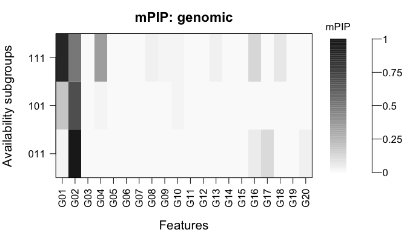

```r
plot(fit, type = "selection", platform = 1)
```

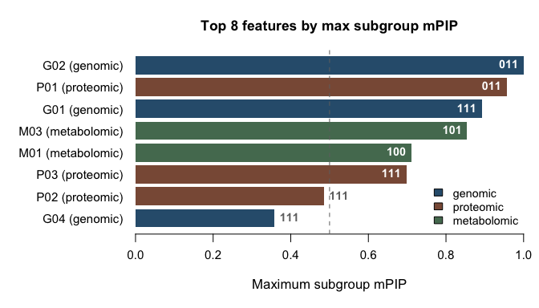

```r
plot_top_features(fit, top = 8)
```

The estimated MRF interaction parameters, which measure how strongly each pair of subgroups shares biomarkers, are shown with `type = "theta"`, and the log-posterior trace with `type = "trace"`.

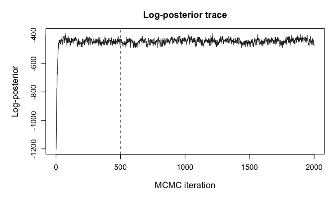

```r
plot(fit, type = "trace")
```

# 5 Predicting new subjects

`predict()` routes new subjects to the appropriate availability subgroup, standardises their features with the training scaling, and performs Bayesian model averaging. When the new platforms are supplied in the same order as at training, `platform_names` can be omitted. Binary outcomes are returned on the probability scale.

```r
new_x <- simIMR$platforms$genomic[1:20, ]
new_p <- simIMR$platforms$proteomic[1:20, ]
pred <- predict(fit, newdata = list(new_x, new_p),
                covariates = simIMR$covariates)
head(pred[["model:011"]])
```

```
#>   id predict
#> 1  1   0.380
#> 2  2   0.388
#> 3  3   0.703
#> 4  4   0.327
#> 5  5   0.737
#> 6  6   0.250
```

# 6 Assessing predictive performance

`cv_imr()` runs repeated $K$-fold splits using the fitted MCMC samples and reports the accuracy measure appropriate to the outcome type (AUC for binary, the concordance index for survival, mean squared error for continuous), overall and within each availability subgroup. The MCMC sampler is not re-run inside each fold; to compare IMR with BMS, fit a separate `method = "BMS"` object.

```r
cv <- cv_imr(fit, k = 5, rounds = 3)
attr(cv, "metric")
```

```
#> [1] "AUC"
```

```r
round(colMeans(cv$total_cindex), 3)
```

```
#>   011   100   101   111   all
#> 0.720 0.599 0.703 0.698 0.681
```

# 7 Other outcome types

The same interface handles continuous and right-censored outcomes; only `type_outcome` and the `outcome` data frame change.

```r
# continuous (Gaussian) outcome
fit_c <- imr(
  simIMR$platforms, simIMR$outcome.continuous, cov = simIMR$covariates,
  type_outcome = "continuous", nu = c(-4, -3, -4),
  sample_mcmc = c(1500, 500), ssize = 30, seed = 1)

# right-censored survival outcome
fit_s <- imr(
  simIMR$platforms, simIMR$outcome.survival, cov = simIMR$covariates,
  type_outcome = "right.censored", nu = c(-4, -3, -4),
  sample_mcmc = c(1500, 500), ssize = 30, seed = 1)
```

# 8 References

Chekouo T, Stingo FC, Doecke JD, Do K-A (2017). “A Bayesian Integrative Approach for Multi-Platform Genomic Data: A Kidney Cancer Case Study.” *Biometrics*, **73**(2), 615–624. doi:10.1111/biom.12587